# Лабораторная работа №10

Расширенные настройки SMTP-сервера

Гашимова Эсма Эльшан кызы

1132247520@rudn.ru

Российский университет дружбы народов

2026-10-22

# Цели и задачи работы

## Цель лабораторной работы

Приобретение практических навыков расширенной настройки и администрирования SMTP-сервера Postfix и почтового сервера Dovecot в операционной системе Rocky Linux.

Настроить доставку почтовых сообщений по протоколу LMTP, реализовать SASL-аутентификацию пользователей и защищённое SMTP-соединение с использованием TLS. Проверить работу почтовых служб через Telnet, OpenSSL и Evolution, а также автоматизировать настройку с помощью Vagrant.

# Процесс выполнения лабораторной работы

## Настройка протокола LMTP в Dovecot

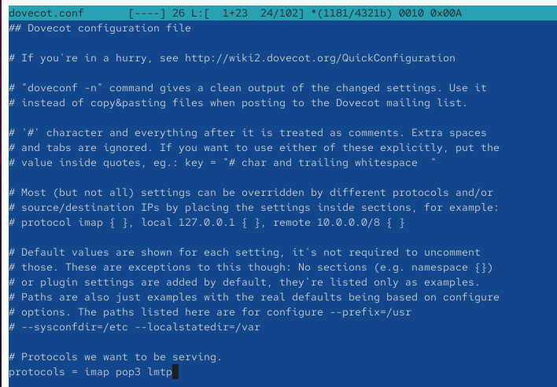

Добавление протокола LMTP в конфигурацию Dovecot

## Настройка службы LMTP

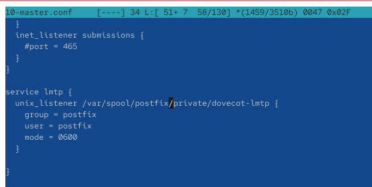

Настройка Unix-сокета для взаимодействия Dovecot с Postfix

## Настройка формата имени пользователя

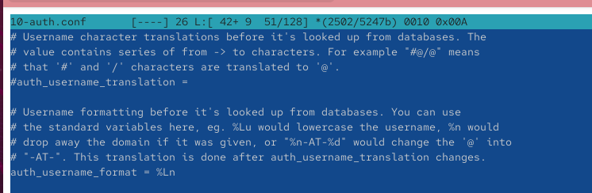

Настройка формата имени пользователя для аутентификации Dovecot

## Проверка отправки сообщения через LMTP

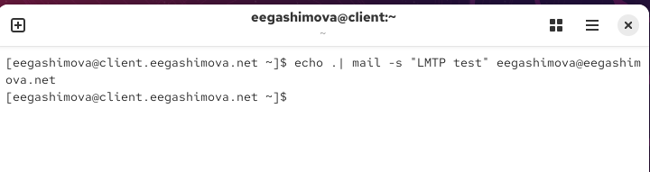

Отправка тестового почтового сообщения для проверки LMTP

## Мониторинг доставки почтовых сообщений

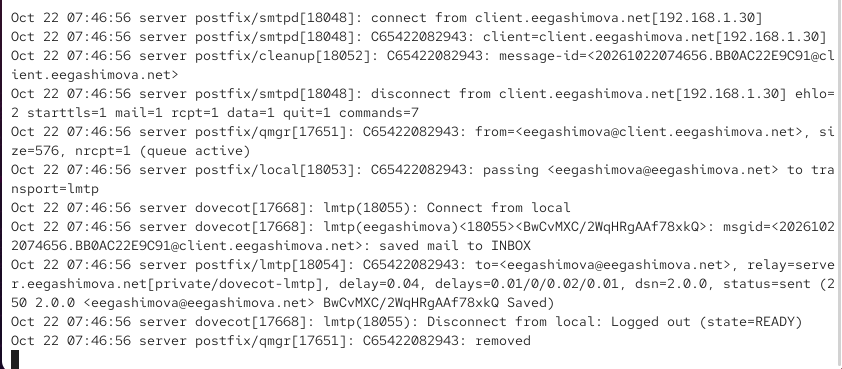

Анализ журнала почтовой службы при доставке сообщения через LMTP

## Проверка почтового ящика на сервере

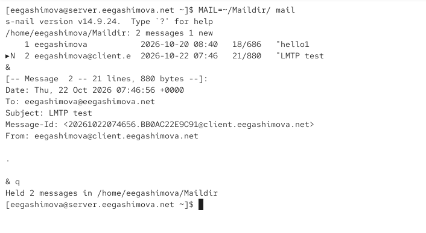

Проверка доставки тестового сообщения в почтовый ящик пользователя

## Настройка службы SASL-аутентификации

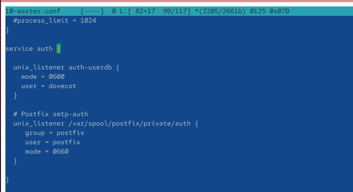

Настройка службы аутентификации Dovecot и Unix-сокета для Postfix

## Настройка SASL в Postfix

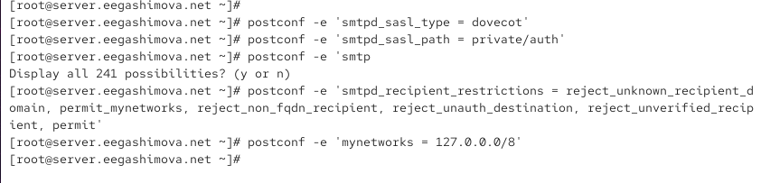

Настройка SASL-аутентификации и ограничений приёма почты в Postfix

## Настройка параметров SMTP-сервера

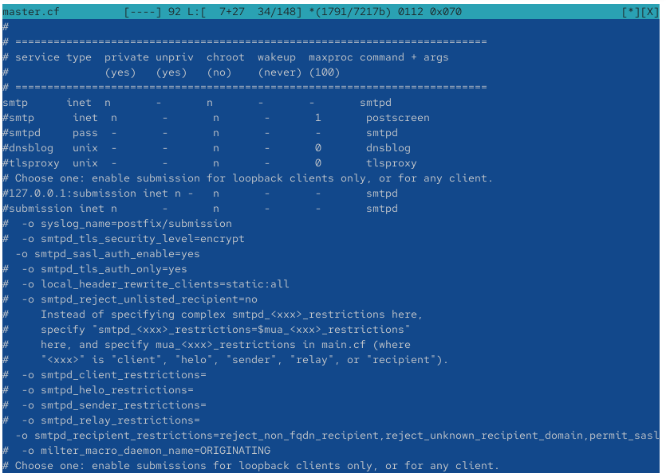

Редактирование конфигурации SMTP-службы в файле master.cf

## Проверка SMTP-аутентификации через Telnet

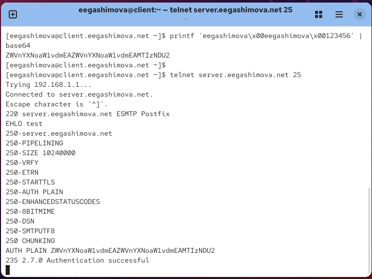

Проверка SASL-аутентификации на SMTP-сервере через Telnet

## Настройка TLS для SMTP-сервера

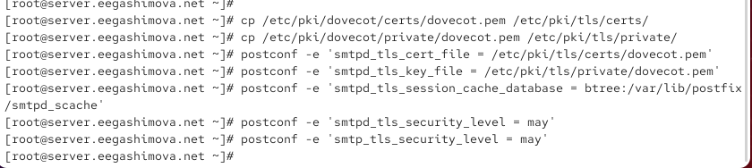

Настройка сертификата, закрытого ключа и параметров TLS в Postfix

## Настройка SMTP Submission

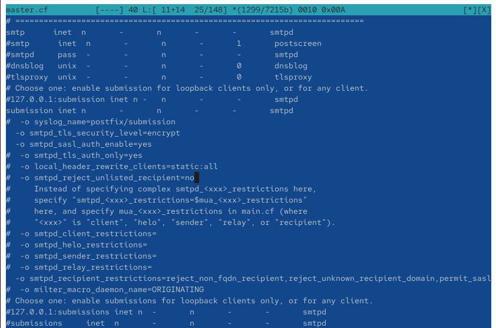

Настройка службы submission на порту 587 с использованием TLS и SASL

## Настройка межсетевого экрана

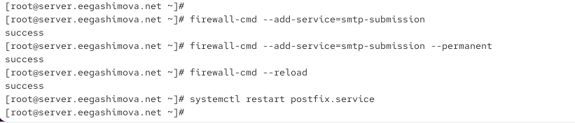

Открытие порта SMTP Submission в межсетевом экране и перезапуск Postfix

## Проверка защищённого SMTP-соединения

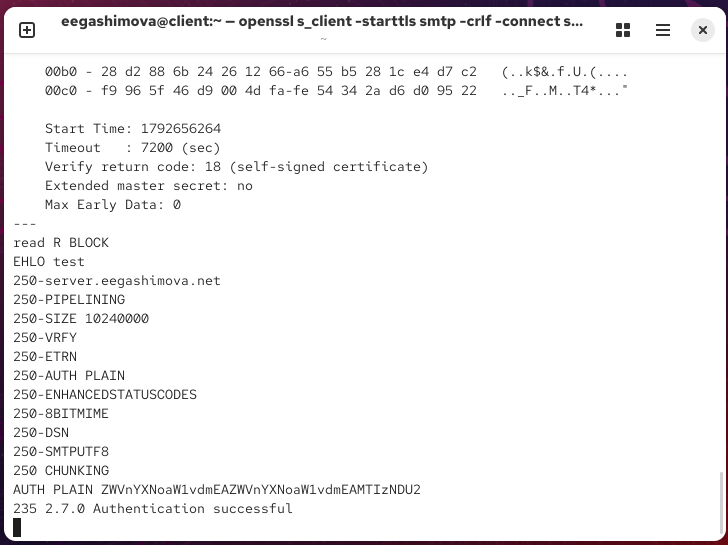

Проверка защищённого SMTP-соединения и SASL-аутентификации через OpenSSL

## Настройка почтового клиента Evolution

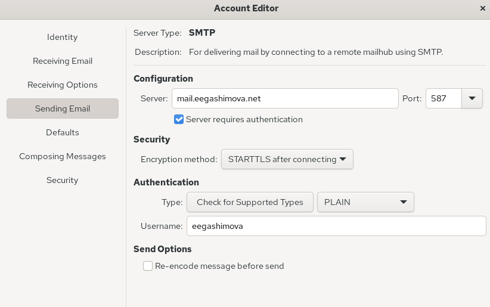

Настройка SMTP-сервера, порта 587 и STARTTLS в почтовом клиенте Evolution

## Проверка получения электронной почты

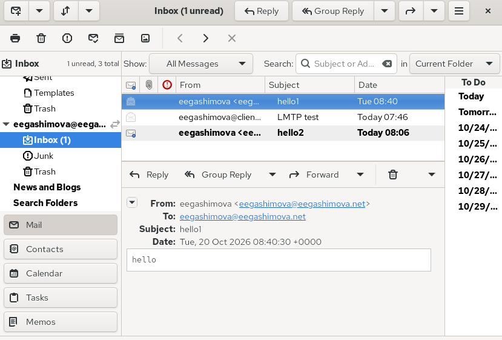

Проверка получения тестового сообщения в почтовом клиенте Evolution

## Анализ журнала почтового сервера

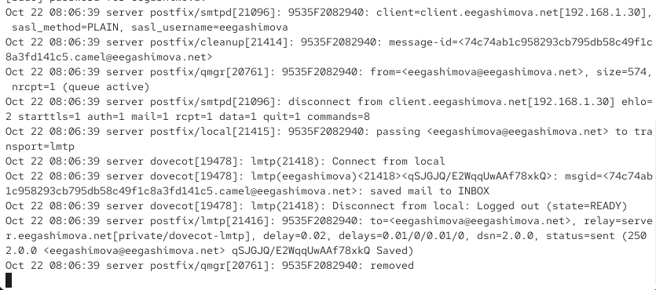

Анализ журнала Postfix и Dovecot после отправки письма через Evolution

## Подготовка конфигурационных файлов

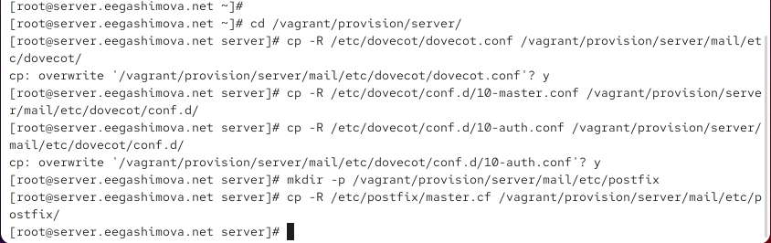

Копирование конфигурационных файлов Dovecot и Postfix в каталог Vagrant

## Изменение сценария mail.sh на сервере

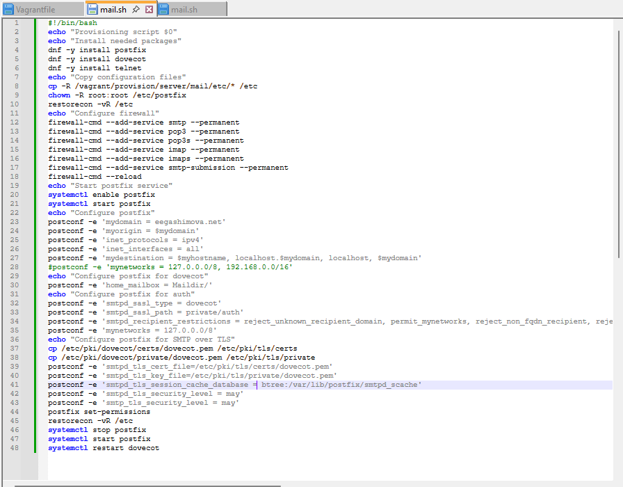

Редактирование скрипта автоматизированной настройки почтового сервера mail.sh

## Изменение сценария mail.sh на клиенте

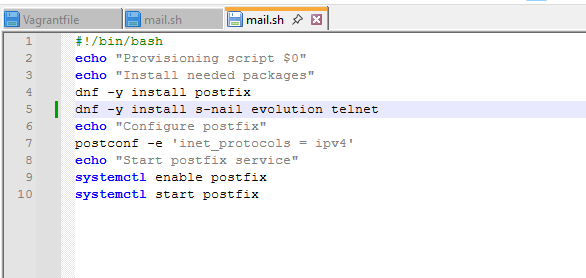

Добавление установки Telnet в скрипт настройки клиентской виртуальной машины

# Результаты работы

## Настройка LMTP и SASL-аутентификации

На виртуальной машине `server` настроено взаимодействие Postfix и Dovecot по протоколу LMTP. Реализована SASL-аутентификация пользователей и установлены ограничения на пересылку почтовых сообщений для предотвращения несанкционированного использования SMTP-сервера.

## Настройка защищённого SMTP-соединения

Настроено TLS-шифрование и служба SMTP Submission на порту `587`. Проверена возможность установления защищённого соединения через OpenSSL и выполнения SASL-аутентификации. В почтовом клиенте Evolution настроена отправка сообщений с использованием STARTTLS.

## Проверка работы почтовой службы

Успешно проверены отправка и получение тестовых сообщений через Evolution, а также аутентификация пользователей через Telnet и OpenSSL. Доставка почты посредством LMTP подтверждена записями в журнале `/var/log/maillog`.

# Вывод

В ходе лабораторной работы была выполнена расширенная настройка SMTP-сервера Postfix и почтового сервера Dovecot на виртуальной машине `server`.

Настроена доставка сообщений по протоколу LMTP, реализована SASL-аутентификация пользователей и обеспечена защищённая передача почты с использованием TLS через порт `587`.

На виртуальной машине `client` проверена работа SMTP-аутентификации через Telnet и OpenSSL, настроен почтовый клиент Evolution и подтверждена успешная отправка и получение тестовых сообщений.